# Objects in R

# R Data Structures

## R Variables are Objects

- The variables in R are technically known as objects
  - Objects should have meaningful names
  - Try to avoid common function names such as mean and sqrt or else it gets confusing
- Object names CANNOT start with a number
- Object names CAN have “.” and numbers within them
- Avoid “_”

```r
# Variables (objects) can be created by = or <-
x <- 'abc'
x = 'abc'
x
```

'abc'

```r
# Determine data type of a variable
typeof(x)
```

'character'

```r
#Determine the number of variables in a variable
length(x)
```

1

```r
# Determine the number of characters in a variable
nchar(x)
```

3

## R Data Types

```r
x <- 4
typeof(x)
y <- 4.8

#Determine data types
typeof(y)
x+y
```

'double'

'double'

8.8

```r
x <- 'a'
typeof(x)
y <- 'Hello There'
typeof(y)
# These data types allow you to know what sort of functions can be performed
# For example numbers can be added but characters can’t be
x+y
```

'character'

'character'

```
Error in x + y: non-numeric argument to binary operator
Traceback:
```

```r
x <- TRUE
typeof(x)
y <- FALSE
typeof(y)
```

'logical'

'logical'

```r
x <- 1+4i
typeof(x)
```

'complex'

```r
x <- c(1:4)
typeof(x)
```

'integer'

## Basic Arithmetic

```r
# Numbers in R need not be given object names

20+3
20-3
20*3
```

23

17

60

```r
20*3
20/3
20^3
```

60

6.66666666666667

8000

```r
20 %% 3 #(remainder of the division)
```

2

```r
20 %/% 3 #(integer of the division)
```

6

```r
z <- 3*3
sqrt(z)
```

3

```r
x <- 20
y <- 3
x + y
x - y
x * y
x / y
x ^ y
x %% y
x %/% y #(integer of the division)
```

23

17

60

6.66666666666667

8000

2

6

## Vectors and Matrices

A vector can be a “collection” of values or a single value

- Atomic vector
  - a collection of values
- Factors
  - special vectors that represent categorical data
- Matrix
  - special vector with rows and columns
- Data frame
  - a special data structure of rows and columns, the default structure for reading in “excel-like” files
- List
  - a vector of different data types (including other vectors)

```r
# Vectors
# An example of a numeric vector
x <- 1
x
y <- c(1:10)
y
length(y)
typeof(y)
```

1

1. 1

2. 2

3. 3

4. 4

5. 5

6. 6

7. 7

8. 8

9. 9

10. 10

10

'integer'

```r
# Vectors can be any datatype (character, logical, complex)
x <- c('a','b','c','d')
x
typeof(x)
```

1. 'a'

2. 'b'

3. 'c'

4. 'd'

'character'

```r
# For Numerical Vectors you can do comparisons

x <- c(1:10)
x
```

1. 1

2. 2

3. 3

4. 4

5. 5

6. 6

7. 7

8. 8

9. 9

10. 10

```r
x > 3
(x > 3) & (x < 8)
x[x > 3]
```

1. FALSE

2. FALSE

3. FALSE

4. TRUE

5. TRUE

6. TRUE

7. TRUE

8. TRUE

9. TRUE

10. TRUE

1. FALSE

2. FALSE

3. FALSE

4. TRUE

5. TRUE

6. TRUE

7. TRUE

8. FALSE

9. FALSE

10. FALSE

1. 4

2. 5

3. 6

4. 7

5. 8

6. 9

7. 10

```r
#Comparisons are logical objects

typeof((x > 3) & (x < 8))
```

'logical'

```r
# Combining Vectors

x <- c(1:10)
x <- c(x,11:20)
x
```

1. 1

2. 2

3. 3

4. 4

5. 5

6. 6

7. 7

8. 8

9. 9

10. 10

11. 11

12. 12

13. 13

14. 14

15. 15

16. 16

17. 17

18. 18

19. 19

20. 20

```r
#Performing Math on Vectors
x <- c(1:10)
x*3
```

1. 3

2. 6

3. 9

4. 12

5. 15

6. 18

7. 21

8. 24

9. 27

10. 30

```r
x[4]
```

4

## Factors Are Nominal Vectors

The factor stores the nominal values as a vector of integers in the range [ 1... k ] and an internal vector of character strings (the original values) mapped to these integers.

```r
genotype <- c(rep(“WT”,5),rep("KO",5))
factor(genotype)
```

```
Error in parse(text = x, srcfile = src): <text>:1:19: unexpected input
1: genotype <- c(rep(<e2>
                      ^
Traceback:
```

```r
genotype <- factor(genotype,levels=c("WT","KO"))
genotype
summary(genotype)
```

```
Error in factor(genotype, levels = c("WT", "KO")): object 'genotype' not found
Traceback:

1. factor(genotype, levels = c("WT", "KO"))
```

```r
genotype <- factor(genotype,levels=c("WT","KO"),ordered=TRUE)
min(genotype)
```

```
Error in factor(genotype, levels = c("WT", "KO"), ordered = TRUE): object 'genotype' not found
Traceback:

1. factor(genotype, levels = c("WT", "KO"), ordered = TRUE)
```

# What is a function

- Built-in functions are operations that one can “perform” on object that are available in R
- User-defined functions are functions that are written by the user
- Packages are R functions that are written by the R community that need to be loaded before using them

## Getting Help with R functions

- R Help
  - The help() function and ? help operator in R provide access to the documentation pages for R functions, data sets, and other objects, both for packages in the standard R distribution and for contributed packages.
  - help()
  - ?
- To access documentation for the standard lm (linear model)
  - help(lm)
  - help("lm")
  - ?lm
  - ?"lm"
  - quotes are optional
- To access help for a function in a package that’s not currently loaded, specify in addition the name of the package:
  - for the rlm() (robust linear model) function in the MASS package:
  - help(rlm, package="MASS")

## Math Functions

```r
# absolute value
x <- -2
abs(x)
```

2

```r
# square root
x <- 4
sqrt(x)
```

2

```r
#Rounding and Creating Integers
x <- 4.693959
n <- 3
ceiling(x)
floor(x)
trunc(x)
round(x, digits=n)
signif(x, digits=n)
```

5

4

4

4.694

4.69

```r
#Triganometry
x <- 60
cos(x)
sin(x)
tan(x)
```

-0.952412980415156

-0.304810621102217

0.320040389379563

```r
#Logarithms and Exponents
x <- 3.2
log(x)
log10(x)
exp(x)
```

1.16315080980568

0.505149978319906

24.5325301971094

```r
# divide continuous variable in factor with n levels
y <- cut(1:20, 20)
y
```

1. (0.981,1.95]

2. (1.95,2.9]

3. (2.9,3.85]

4. (3.85,4.8]

5. (4.8,5.75]

6. (5.75,6.7]

7. (6.7,7.65]

8. (7.65,8.6]

9. (8.6,9.55]

10. (9.55,10.5]

11. (10.5,11.4]

12. (11.4,12.4]

13. (12.4,13.3]

14. (13.3,14.3]

15. (14.3,15.2]

16. (15.2,16.2]

17. (16.2,17.1]

18. (17.1,18.1]

19. (18.1,19.1]

20. (19.1,20]

**Levels**:**

1. '(0.981,1.95]'

2. '(1.95,2.9]'

3. '(2.9,3.85]'

4. '(3.85,4.8]'

5. '(4.8,5.75]'

6. '(5.75,6.7]'

7. '(6.7,7.65]'

8. '(7.65,8.6]'

9. '(8.6,9.55]'

10. '(9.55,10.5]'

11. '(10.5,11.4]'

12. '(11.4,12.4]'

13. '(12.4,13.3]'

14. '(13.3,14.3]'

15. '(14.3,15.2]'

16. '(15.2,16.2]'

17. '(16.2,17.1]'

18. '(17.1,18.1]'

19. '(18.1,19.1]'

20. '(19.1,20]'

## String Manipulation

```r
# generate a sequence
indices <- seq(1,10,2)

# Repeat a string

rep('a',3)
```

1. 'a'

2. 'a'

3. 'a'

```r
# Extract or replace substrings in a character vector.
#substr(x, start=n1, stop=n2)
x <- "abcdef"
substr(x, 2, 4)
substr(x, 2, 4) <- "22222"

a <- "Hello"
substring(a,1,2)
substring(a,2,5)
```

'bcd'

'He'

'ello'

```r
# Search for pattern in x. If fixed =FALSE then pattern is a regular expression.
# If fixed=TRUE then pattern is a text string. Returns matching indices.
#grep(pattern, x , ignore.case=FALSE, fixed=FALSE)

grep("A", c("b","A","c"), fixed=TRUE)
```

2

```r
# Find pattern in x and replace with replacement text. If fixed=FALSE then pattern is a regular expression.
# If fixed = T then pattern is a text string.
#sub(pattern, replacement, x, ignore.case =FALSE, fixed=FALSE)

sub("\\s",".","Hello There")
```

'Hello.There'

```r
#Split the elements of character vector x at split.
#strsplit(x, split)

strsplit("abc", "")
```

1. 1. 'a'

   2. 'b'

   3. 'c'

```r
#Concatenate strings after using sep string to seperate them.
#paste(..., sep="")

paste('x',1:3,sep="")
paste('x',1:3,sep="M")
paste('Today is', date())

a <- "Hello"
b <- 'How'
c <- "are you?"
print(paste(a,b,c))
print(paste(a,b,c, sep = "-"))
print(paste(a,b,c, sep = "", collapse = ""))
```

1. 'x1'

2. 'x2'

3. 'x3'

1. 'xM1'

2. 'xM2'

3. 'xM3'

'Today is Wed Jul 4 11:54:04 2018'

```
[1] "Hello How are you?"
[1] "Hello-How-are you?"
[1] "HelloHoware you?"
```

```r
# Create Upper and Lowercase strings
x <- 'Hello There'
toupper(x)
tolower(x)
```

'HELLO THERE'

'hello there'

# Built In Statistical Functions

## Means, Medians, Ranges and Other Basic Functions on Number Sets

```r
x <- 1:20
mean(x)
sd(x)
median(x)
min(x)
max(x)
```

10.5

5.91607978309962

10.5

1

20

```r
quantile(x)
```

**0%**

1

**25%**

5.75

**50%**

10.5

**75%**

15.25

**100%**

20

1. 1

2. 20

210

1. 1

2. 1

3. 1

4. 1

5. 1

6. 1

7. 1

8. 1

9. 1

10. 1

11. 1

12. 1

13. 1

14. 1

15. 1

16. 1

17. 1

18. 1

19. 1

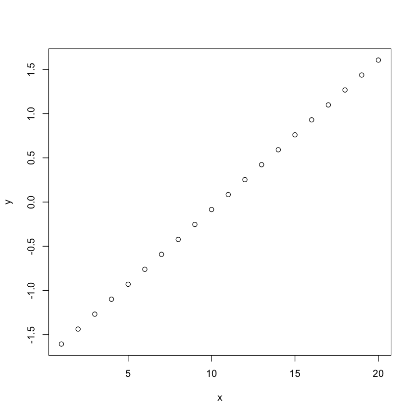

```r
range(x)
sum(x)
diff(x, lag=1)
y <- scale(x, center=TRUE, scale=TRUE)
plot(x,y)
```

## Normal Distribution

- dnorm(x)
- pnorm(q)
- qnorm(p)
- rnorm(n, m=0,sd=1)

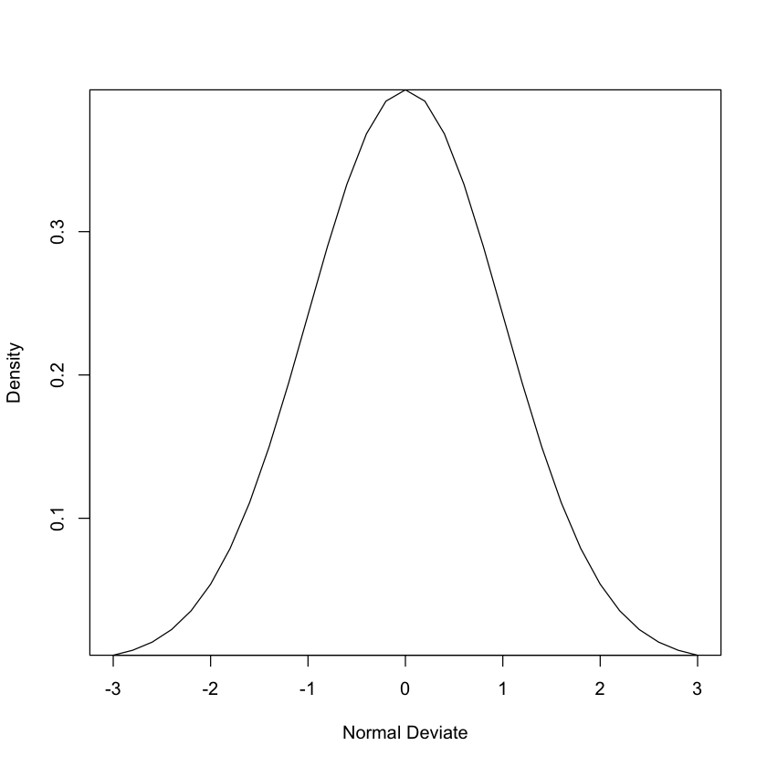

```r
#normal density function (by default m=0 sd=1)
# plot standard normal curve
x <- pretty(c(-3,3), 30)
y <- dnorm(x)
plot(x, y, type='l', xlab="Normal Deviate", ylab="Density", yaxs="i")
```

```r
#cumulative normal probability for q
#(area under the normal curve to the left of q)
pnorm(1.96)
```

0.97500210485178

```r
#normal quantile.
#value at the p percentile of normal distribution
qnorm(.9)
```

1.2815515655446

```r
#n random normal deviates with mean m and standard deviation sd.
#50 random normal variates with mean=50, sd=10
x <- rnorm(50, m=50, sd=10)
x
```

1. 56.6593084122963

2. 60.155317653088

3. 55.9083150728

4. 42.7956776967685

5. 48.1538238204272

6. 61.2491412601765

7. 42.1120560973629

8. 29.8359394706739

9. 45.8338910253642

10. 58.2448515583633

11. 38.6109669417492

12. 62.0962376168555

13. 68.5203253007431

14. 36.2190694151207

15. 60.1039979053207

16. 42.2388179502121

17. 27.2779567858732

18. 53.9431384260507

19. 43.418241734822

20. 49.5180042989959

21. 49.904999082633

22. 39.8515765295455

23. 56.8724909716531

24. 52.5112200161407

25. 58.4144867894071

26. 56.1534851022861

27. 64.2174994728223

28. 54.4695716892177

29. 63.2337816079386

30. 26.8765566849792

31. 63.5395107191654

32. 56.4947166745401

33. 38.5082922785383

34. 44.984078651159

35. 51.0389344888757

36. 51.7443141145394

37. 50.3855085642358

38. 62.4231746924192

39. 53.415130743734

40. 36.5536444124325

41. 39.3893628531487

42. 31.915579161233

43. 59.171492260718

44. 44.7482169887281

45. 50.8543498764551

46. 45.4870324232751

47. 50.1850815937212

48. 39.8624749665707

49. 61.4501816873907

50. 50.4804472120022

## Binomial Distribution

binomial distribution where size is the sample size and prob is the probability of a heads (for a coin toss)

- dbinom(x, size, prob)
- pbinom(q, size, prob)
- qbinom(p, size, prob)
- rbinom(n, size, prob)

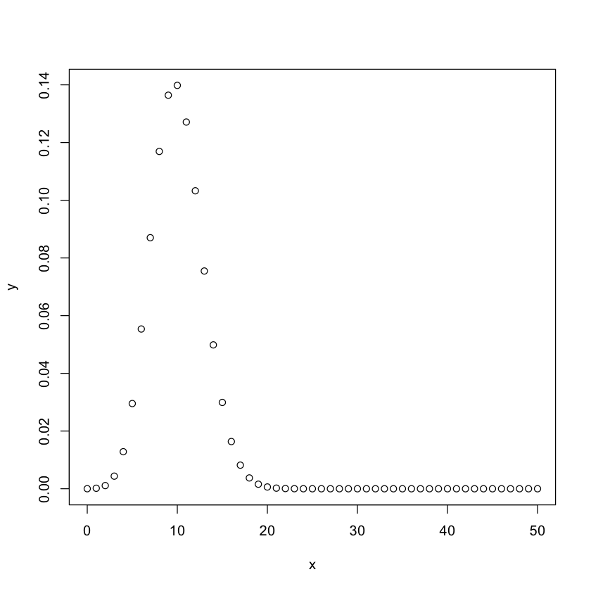

```r
x <- seq(0,50,by=1)
y <- dbinom(x,50,0.2)
plot(x,y)
```

## Poisson Distribution

poisson distribution with m=std=lamda

- dpois(x, lamda)
- ppois(q, lamda)
- qpois(p, lamda)
- rpois(n, lamda)

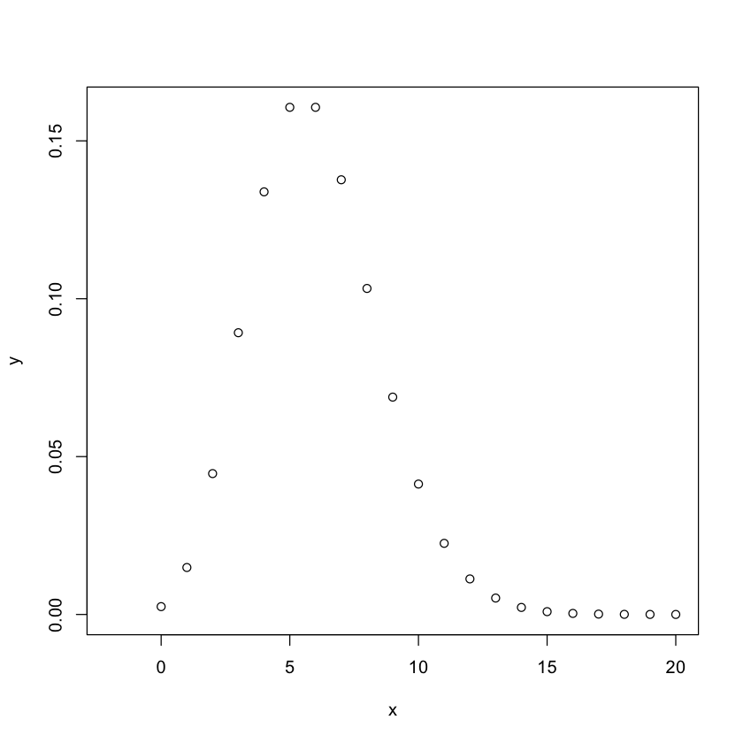

```r
x <- 0:20
y <- dpois( x=0:20, lambda=6 )
plot(x, y, xlim=c(-2,20))
```

## Uniform Distribution

- dunif(x, min=0, max=1)
- punif(q, min=0, max=1)
- qunif(p, min=0, max=1)
- runif(n, min=0, max=1)

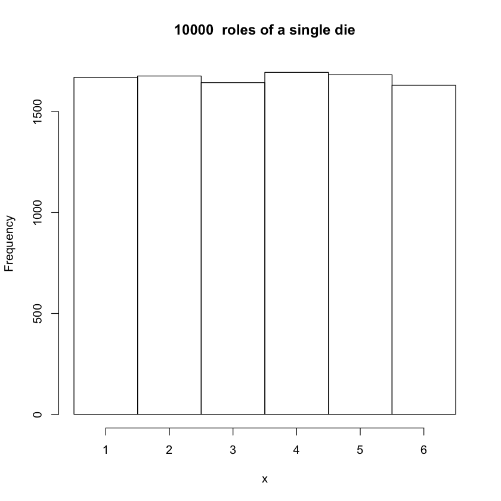

```r
numcases <- 10000
min <- 1
max <- 6
x <- as.integer(runif(numcases,min,max+1))
hist(x,main=paste( numcases," roles of a single die"),breaks=seq(min-.5,max+.5,1))
```

# Matrix

special vector with rows and columns

- All columns in a matrix must have the same mode(numeric, character, etc.) and the same length. The general format is:
  - mymatrix <- matrix(vector, nrow=r, ncol=c, byrow=FALSE)
- byrow=TRUE indicates that the matrix should be filled by rows.
- byrow=FALSE indicates that the matrix should be filled by columns (the default)

```r
y <- matrix(1:20, nrow=5,ncol=4)
y
cells <- c(1,26,24,68)
rnames <- c("R1", "R2")
cnames <- c("C1", "C2")
x <- matrix(cells, nrow=2, ncol=2, byrow=TRUE, dimnames=list(rnames, cnames))
x
```

| 1 | 6 | 11 | 16 |
| --- | --- | --- | --- |
| 2 | 7 | 12 | 17 |
| 3 | 8 | 13 | 18 |
| 4 | 9 | 14 | 19 |
| 5 | 10 | 15 | 20 |

|  | C1 | C2 |
| --- | --- | --- |
| R1 | 1 | 26 |
| R2 | 24 | 68 |

```r
x[,1] # 1st column of matrix
x[2,] # 2nd row of matrix
x[2,1] # row 2, column 1
x[1,2]
```

**R1**

1

**R2**

24

**C1**

24

**C2**

68

24

26

## Functions to Combine and Calculate Statistics on Matrices

- cbind(A,B,...)
  - Combine matrices(vectors) horizontally. Returns a matrix.
- rbind(A,B,...)
  - Combine matrices(vectors) vertically. Returns a matrix.
- rowMeans(A)
  - Returns vector of row means.
- rowSums(A)
  - Returns vector of row sums.
- colMeans(A)
  - Returns vector of column means.
- colSums(A)
  - Returns vector of column sums.
- t(A)
  - Transpose

```r
y <- matrix(1:20, nrow=5,ncol=4,byrow = FALSE)
y
y <- matrix(1:20, nrow=5,ncol=4,byrow = TRUE)
y
t(y) #transpose
rowSums(y)
colMeans(y)
```

| 1 | 6 | 11 | 16 |
| --- | --- | --- | --- |
| 2 | 7 | 12 | 17 |
| 3 | 8 | 13 | 18 |
| 4 | 9 | 14 | 19 |
| 5 | 10 | 15 | 20 |

| 1 | 2 | 3 | 4 |
| --- | --- | --- | --- |
| 5 | 6 | 7 | 8 |
| 9 | 10 | 11 | 12 |
| 13 | 14 | 15 | 16 |
| 17 | 18 | 19 | 20 |

| 1 | 5 | 9 | 13 | 17 |
| --- | --- | --- | --- | --- |
| 2 | 6 | 10 | 14 | 18 |
| 3 | 7 | 11 | 15 | 19 |
| 4 | 8 | 12 | 16 | 20 |

1. 10

2. 26

3. 42

4. 58

5. 74

1. 9

2. 10

3. 11

4. 12

```r
y*4
y*y
y/y
```

| 4 | 8 | 12 | 16 |
| --- | --- | --- | --- |
| 20 | 24 | 28 | 32 |
| 36 | 40 | 44 | 48 |
| 52 | 56 | 60 | 64 |
| 68 | 72 | 76 | 80 |

| 1 | 4 | 9 | 16 |
| --- | --- | --- | --- |
| 25 | 36 | 49 | 64 |
| 81 | 100 | 121 | 144 |
| 169 | 196 | 225 | 256 |
| 289 | 324 | 361 | 400 |

| 1 | 1 | 1 | 1 |
| --- | --- | --- | --- |
| 1 | 1 | 1 | 1 |
| 1 | 1 | 1 | 1 |
| 1 | 1 | 1 | 1 |
| 1 | 1 | 1 | 1 |

```r
# Element-wise multiplication
A %*% B

# Outer product. AB

A %o% B

# A'B and A'A respectively.

crossprod(A,B)
crossprod(A)
```

```
Error in eval(expr, envir, enclos): object 'A' not found
Traceback:
```

```r
# Creates diagonal matrix with elements of x in the principal diagonal
#Returns a vector containing the elements of the principal diagonal

diag(y)

#If k is a scalar, this creates a k x k identity matrix. Go figure.
diag(4)
```

1. 1

2. 6

3. 11

4. 16

| 1 | 0 | 0 | 0 |
| --- | --- | --- | --- |
| 0 | 1 | 0 | 0 |
| 0 | 0 | 1 | 0 |
| 0 | 0 | 0 | 1 |

# Data Frames

- A special data structure of rows and columns, the default structure for reading in “excel-like” files
- A data frame is more general than a matrix, in that different columns can have different modes (numeric, character, factor, etc.). This is similar to SAS and SPSS datasets.

```r
d <- c(1,2,3,4)
e <- c("red", "white", "red", NA)
f <- c(TRUE,TRUE,TRUE,FALSE)
x <- data.frame(d,e,f)
names(x) <- c("ID","Color","Passed")
x
```

| ID | Color | Passed |
| --- | --- | --- |
| 1 | red | TRUE |
| 2 | white | TRUE |
| 3 | red | TRUE |
| 4 | NA | FALSE |

```r
setwd("~/Desktop/")
tbl <- read.csv(file="sample_example_R1_data_structures.csv",header=TRUE)
tbl
```

| SampleID | Tissue | SampleGroup | SubjectID | Organism | Race | SampleName | Gender | FullPathToFqR1 | FullPathToFqR2 |
| --- | --- | --- | --- | --- | --- | --- | --- | --- | --- |
| SRR1551074 | Whole.Blood | whole_blood | 53 | Homo sapiens | White | 53_Tempus | female | /project/BICF/s166458/pipeline_devel/SRR1551074_1.fastq.gz | /project/BICF/s166458/pipeline_devel/SRR1551074_2.fastq.gz |
| SRR1551073 | Whole.Blood | NK | 53 | Homo sapiens | White | 53_NK | female | /project/BICF/s166458/pipeline_devel/SRR1551073_1.fastq.gz | /project/BICF/s166458/pipeline_devel/SRR1551073_2.fastq.gz |
| SRR1551072 | Whole.Blood | CD8 | 53 | Homo sapiens | White | 53_CD8T | female | /project/BICF/s166458/pipeline_devel/SRR1551072_1.fastq.gz | /project/BICF/s166458/pipeline_devel/SRR1551072_2.fastq.gz |
| SRR1551071 | Whole.Blood | CD4 | 53 | Homo sapiens | White | 53_CD4T | female | /project/BICF/s166458/pipeline_devel/SRR1551071_1.fastq.gz | /project/BICF/s166458/pipeline_devel/SRR1551071_2.fastq.gz |
| SRR1551070 | Whole.Blood | B-Cells | 53 | Homo sapiens | White | 53_Bcells | female | /project/BICF/s166458/pipeline_devel/SRR1551070_1.fastq.gz | /project/BICF/s166458/pipeline_devel/SRR1551070_2.fastq.gz |
| SRR1551069 | Whole.Blood | monocytes | 53 | Homo sapiens | White | 53_Monocytes | female | /project/BICF/s166458/pipeline_devel/SRR1551069_1.fastq.gz | /project/BICF/s166458/pipeline_devel/SRR1551069_2.fastq.gz |
| SRR1551068 | Whole.Blood | neutrophils | 53 | Homo sapiens | White | 53_Neutrophils | female | /project/BICF/s166458/pipeline_devel/SRR1551068_1.fastq.gz | /project/BICF/s166458/pipeline_devel/SRR1551068_2.fastq.gz |
| SRR1551060 | Whole.Blood | whole_blood | 21 | Homo sapiens | White | 21_Tempus | female | /project/BICF/s166458/pipeline_devel/SRR1551060_1.fastq.gz | /project/BICF/s166458/pipeline_devel/SRR1551060_2.fastq.gz |
| SRR1551059 | Whole.Blood | NK | 21 | Homo sapiens | White | 21_NK | female | /project/BICF/s166458/pipeline_devel/SRR1551059_1.fastq.gz | /project/BICF/s166458/pipeline_devel/SRR1551059_2.fastq.gz |
| SRR1551058 | Whole.Blood | CD8 | 21 | Homo sapiens | White | 21_CD8T | female | /project/BICF/s166458/pipeline_devel/SRR1551058_1.fastq.gz | /project/BICF/s166458/pipeline_devel/SRR1551058_2.fastq.gz |
| SRR1551057 | Whole.Blood | CD4 | 21 | Homo sapiens | White | 21_CD4T | female | /project/BICF/s166458/pipeline_devel/SRR1551057_1.fastq.gz | /project/BICF/s166458/pipeline_devel/SRR1551057_2.fastq.gz |
| SRR1551056 | Whole.Blood | B-Cells | 21 | Homo sapiens | White | 21_Bcells | female | /project/BICF/s166458/pipeline_devel/SRR1551056_1.fastq.gz | /project/BICF/s166458/pipeline_devel/SRR1551056_2.fastq.gz |
| SRR1551055 | Whole.Blood | monocytes | 21 | Homo sapiens | White | 21_Monocytes | female | /project/BICF/s166458/pipeline_devel/SRR1551055_1.fastq.gz | /project/BICF/s166458/pipeline_devel/SRR1551055_2.fastq.gz |
| SRR1551054 | Whole.Blood | neutrophils | 21 | Homo sapiens | White | 21_Neutrophils | female | /project/BICF/s166458/pipeline_devel/SRR1551054_1.fastq.gz | /project/BICF/s166458/pipeline_devel/SRR1551054_2.fastq.gz |
| SRR1551053 | Whole.Blood | whole_blood | 20 | Homo sapiens | White | 20_Tempus | female | /project/BICF/s166458/pipeline_devel/SRR1551053_1.fastq.gz | /project/BICF/s166458/pipeline_devel/SRR1551053_2.fastq.gz |
| SRR1551052 | Whole.Blood | NK | 20 | Homo sapiens | White | 20_NK | female | /project/BICF/s166458/pipeline_devel/SRR1551052_1.fastq.gz | /project/BICF/s166458/pipeline_devel/SRR1551052_2.fastq.gz |
| SRR1551051 | Whole.Blood | CD8 | 20 | Homo sapiens | White | 20_CD8T | female | /project/BICF/s166458/pipeline_devel/SRR1551051_1.fastq.gz | /project/BICF/s166458/pipeline_devel/SRR1551051_2.fastq.gz |
| SRR1551050 | Whole.Blood | CD4 | 20 | Homo sapiens | White | 20_CD4T | female | /project/BICF/s166458/pipeline_devel/SRR1551050_1.fastq.gz | /project/BICF/s166458/pipeline_devel/SRR1551050_2.fastq.gz |
| SRR1551049 | Whole.Blood | B-Cells | 20 | Homo sapiens | White | 20_Bcells | female | /project/BICF/s166458/pipeline_devel/SRR1551049_1.fastq.gz | /project/BICF/s166458/pipeline_devel/SRR1551049_2.fastq.gz |
| SRR1551048 | Whole.Blood | monocytes | 20 | Homo sapiens | White | 20_Monocytes | female | /project/BICF/s166458/pipeline_devel/SRR1551048_1.fastq.gz | /project/BICF/s166458/pipeline_devel/SRR1551048_2.fastq.gz |
| SRR1551047 | Whole.Blood | neutrophils | 20 | Homo sapiens | White | 20_Neutrophils | female | /project/BICF/s166458/pipeline_devel/SRR1551047_1.fastq.gz | /project/BICF/s166458/pipeline_devel/SRR1551047_2.fastq.gz |
| SRR1550991 | Whole.Blood | NK | 44 | Homo sapiens | Hispanic | 44_NK | female | /project/BICF/s166458/pipeline_devel/SRR1550991_1.fastq.gz | /project/BICF/s166458/pipeline_devel/SRR1550991_2.fastq.gz |
| SRR1550990 | Whole.Blood | CD8 | 44 | Homo sapiens | Hispanic | 44_CD8T | female | /project/BICF/s166458/pipeline_devel/SRR1550990_1.fastq.gz | /project/BICF/s166458/pipeline_devel/SRR1550990_2.fastq.gz |
| SRR1550989 | Whole.Blood | CD4 | 44 | Homo sapiens | Hispanic | 44_CD4T | female | /project/BICF/s166458/pipeline_devel/SRR1550989_1.fastq.gz | /project/BICF/s166458/pipeline_devel/SRR1550989_2.fastq.gz |
| SRR1550988 | Whole.Blood | B-Cells | 44 | Homo sapiens | Hispanic | 44_Bcells | female | /project/BICF/s166458/pipeline_devel/SRR1550988_1.fastq.gz | /project/BICF/s166458/pipeline_devel/SRR1550988_2.fastq.gz |
| SRR1550987 | Whole.Blood | monocytes | 44 | Homo sapiens | Hispanic | 44_Monocytes | female | /project/BICF/s166458/pipeline_devel/SRR1550987_1.fastq.gz | /project/BICF/s166458/pipeline_devel/SRR1550987_2.fastq.gz |
| SRR1550986 | Whole.Blood | neutrophils | 44 | Homo sapiens | Hispanic | 44_Neutrophils | female | /project/BICF/s166458/pipeline_devel/SRR1550986_1.fastq.gz | /project/BICF/s166458/pipeline_devel/SRR1550986_2.fastq.gz |
| SRR1550981 | Whole.Blood | whole_blood | 44 | Homo sapiens | Hispanic | 44_Tempus | female | /project/BICF/s166458/pipeline_devel/SRR1550981_1.fastq.gz | /project/BICF/s166458/pipeline_devel/SRR1550981_2.fastq.gz |

```r
tbl[3:5]
```

| SampleGroup | SubjectID | Organism |
| --- | --- | --- |
| whole_blood | 53 | Homo sapiens |
| NK | 53 | Homo sapiens |
| CD8 | 53 | Homo sapiens |
| CD4 | 53 | Homo sapiens |
| B-Cells | 53 | Homo sapiens |
| monocytes | 53 | Homo sapiens |
| neutrophils | 53 | Homo sapiens |
| whole_blood | 21 | Homo sapiens |
| NK | 21 | Homo sapiens |
| CD8 | 21 | Homo sapiens |
| CD4 | 21 | Homo sapiens |
| B-Cells | 21 | Homo sapiens |
| monocytes | 21 | Homo sapiens |
| neutrophils | 21 | Homo sapiens |
| whole_blood | 20 | Homo sapiens |
| NK | 20 | Homo sapiens |
| CD8 | 20 | Homo sapiens |
| CD4 | 20 | Homo sapiens |
| B-Cells | 20 | Homo sapiens |
| monocytes | 20 | Homo sapiens |
| neutrophils | 20 | Homo sapiens |
| NK | 44 | Homo sapiens |
| CD8 | 44 | Homo sapiens |
| CD4 | 44 | Homo sapiens |
| B-Cells | 44 | Homo sapiens |
| monocytes | 44 | Homo sapiens |
| neutrophils | 44 | Homo sapiens |
| whole_blood | 44 | Homo sapiens |

```r
tbl[c("SampleID","Tissue")]
```

| SampleID | Tissue |
| --- | --- |
| SRR1551074 | Whole.Blood |
| SRR1551073 | Whole.Blood |
| SRR1551072 | Whole.Blood |
| SRR1551071 | Whole.Blood |
| SRR1551070 | Whole.Blood |
| SRR1551069 | Whole.Blood |
| SRR1551068 | Whole.Blood |
| SRR1551060 | Whole.Blood |
| SRR1551059 | Whole.Blood |
| SRR1551058 | Whole.Blood |
| SRR1551057 | Whole.Blood |
| SRR1551056 | Whole.Blood |
| SRR1551055 | Whole.Blood |
| SRR1551054 | Whole.Blood |
| SRR1551053 | Whole.Blood |
| SRR1551052 | Whole.Blood |
| SRR1551051 | Whole.Blood |
| SRR1551050 | Whole.Blood |
| SRR1551049 | Whole.Blood |
| SRR1551048 | Whole.Blood |
| SRR1551047 | Whole.Blood |
| SRR1550991 | Whole.Blood |
| SRR1550990 | Whole.Blood |
| SRR1550989 | Whole.Blood |
| SRR1550988 | Whole.Blood |
| SRR1550987 | Whole.Blood |
| SRR1550986 | Whole.Blood |
| SRR1550981 | Whole.Blood |

```r
tbl$Gender
```

1. female

2. female

3. female

4. female

5. female

6. female

7. female

8. female

9. female

10. female

11. female

12. female

13. female

14. female

15. female

16. female

17. female

18. female

19. female

20. female

21. female

22. female

23. female

24. female

25. female

26. female

27. female

28. female

**Levels**:**

'female'

```r
tbl[tbl$SampleGroup == 'monocytes',]
```

|  | SampleID | Tissue | SampleGroup | SubjectID | Organism | Race | SampleName | Gender | FullPathToFqR1 | FullPathToFqR2 |
| --- | --- | --- | --- | --- | --- | --- | --- | --- | --- | --- |
| 6 | SRR1551069 | Whole.Blood | monocytes | 53 | Homo sapiens | White | 53_Monocytes | female | /project/BICF/s166458/pipeline_devel/SRR1551069_1.fastq.gz | /project/BICF/s166458/pipeline_devel/SRR1551069_2.fastq.gz |
| 13 | SRR1551055 | Whole.Blood | monocytes | 21 | Homo sapiens | White | 21_Monocytes | female | /project/BICF/s166458/pipeline_devel/SRR1551055_1.fastq.gz | /project/BICF/s166458/pipeline_devel/SRR1551055_2.fastq.gz |
| 20 | SRR1551048 | Whole.Blood | monocytes | 20 | Homo sapiens | White | 20_Monocytes | female | /project/BICF/s166458/pipeline_devel/SRR1551048_1.fastq.gz | /project/BICF/s166458/pipeline_devel/SRR1551048_2.fastq.gz |
| 26 | SRR1550987 | Whole.Blood | monocytes | 44 | Homo sapiens | Hispanic | 44_Monocytes | female | /project/BICF/s166458/pipeline_devel/SRR1550987_1.fastq.gz | /project/BICF/s166458/pipeline_devel/SRR1550987_2.fastq.gz |

```r
subset(x=tbl,SampleGroup == 'monocytes',select=c('Tissue','SampleID'))
```

|  | Tissue | SampleID |
| --- | --- | --- |
| 6 | Whole.Blood | SRR1551069 |
| 13 | Whole.Blood | SRR1551055 |
| 20 | Whole.Blood | SRR1551048 |
| 26 | Whole.Blood | SRR1550987 |

```r
tbl1 <- read.csv(file="sample_example_R1_data_structures.csv",header=TRUE)
tbl2 <- read.csv(file="table2.csv",header=TRUE)
tbl2
```

| SampleID | SubjectID | BMI |
| --- | --- | --- |
| SRR1551074 | 53 | 23 |
| SRR1551073 | 53 | 23 |
| SRR1551072 | 53 | 23 |
| SRR1551071 | 53 | 23 |
| SRR1551070 | 53 | 23 |
| SRR1551069 | 53 | 23 |
| SRR1551068 | 53 | 23 |
| SRR1551060 | 21 | 28 |
| SRR1551059 | 21 | 28 |
| SRR1551058 | 21 | 28 |
| SRR1551057 | 21 | 28 |
| SRR1551056 | 21 | 28 |
| SRR1551055 | 21 | 28 |
| SRR1551054 | 21 | 28 |
| SRR1551053 | 20 | 35 |
| SRR1551052 | 20 | 35 |
| SRR1551051 | 20 | 35 |
| SRR1551050 | 20 | 35 |
| SRR1551049 | 20 | 35 |
| SRR1551048 | 20 | 35 |
| SRR1551047 | 20 | 35 |
| SRR1550991 | 44 | 40 |
| SRR1550990 | 44 | 40 |
| SRR1550989 | 44 | 40 |
| SRR1550988 | 44 | 40 |
| SRR1550987 | 44 | 40 |
| SRR1550986 | 44 | 40 |
| SRR1550981 | 44 | 40 |

- gives a very brief description of the data
  - str(df)
- gives the name of each variables
  - names(df)
- gives some very basic summary statistics for each variable
  - summary(df)
- shows the first few rows
  - head(df)
- shows the last few rows.
  - tail(df)
- looks at duplicated elements and returns a logical vector. You can use table() to summarize this vector.
  - duplicated()
- keeps only the unique lines in a dataset
  - unique()

```r
merge.tbl <- merge(tbl1,tbl2,by='SampleID')
merge.tbl
```

| SampleID | Tissue | SampleGroup | SubjectID.x | Organism | Race | SampleName | Gender | FullPathToFqR1 | FullPathToFqR2 | SubjectID.y | BMI |
| --- | --- | --- | --- | --- | --- | --- | --- | --- | --- | --- | --- |
| SRR1550981 | Whole.Blood | whole_blood | 44 | Homo sapiens | Hispanic | 44_Tempus | female | /project/BICF/s166458/pipeline_devel/SRR1550981_1.fastq.gz | /project/BICF/s166458/pipeline_devel/SRR1550981_2.fastq.gz | 44 | 40 |
| SRR1550986 | Whole.Blood | neutrophils | 44 | Homo sapiens | Hispanic | 44_Neutrophils | female | /project/BICF/s166458/pipeline_devel/SRR1550986_1.fastq.gz | /project/BICF/s166458/pipeline_devel/SRR1550986_2.fastq.gz | 44 | 40 |
| SRR1550987 | Whole.Blood | monocytes | 44 | Homo sapiens | Hispanic | 44_Monocytes | female | /project/BICF/s166458/pipeline_devel/SRR1550987_1.fastq.gz | /project/BICF/s166458/pipeline_devel/SRR1550987_2.fastq.gz | 44 | 40 |
| SRR1550988 | Whole.Blood | B-Cells | 44 | Homo sapiens | Hispanic | 44_Bcells | female | /project/BICF/s166458/pipeline_devel/SRR1550988_1.fastq.gz | /project/BICF/s166458/pipeline_devel/SRR1550988_2.fastq.gz | 44 | 40 |
| SRR1550989 | Whole.Blood | CD4 | 44 | Homo sapiens | Hispanic | 44_CD4T | female | /project/BICF/s166458/pipeline_devel/SRR1550989_1.fastq.gz | /project/BICF/s166458/pipeline_devel/SRR1550989_2.fastq.gz | 44 | 40 |
| SRR1550990 | Whole.Blood | CD8 | 44 | Homo sapiens | Hispanic | 44_CD8T | female | /project/BICF/s166458/pipeline_devel/SRR1550990_1.fastq.gz | /project/BICF/s166458/pipeline_devel/SRR1550990_2.fastq.gz | 44 | 40 |
| SRR1550991 | Whole.Blood | NK | 44 | Homo sapiens | Hispanic | 44_NK | female | /project/BICF/s166458/pipeline_devel/SRR1550991_1.fastq.gz | /project/BICF/s166458/pipeline_devel/SRR1550991_2.fastq.gz | 44 | 40 |
| SRR1551047 | Whole.Blood | neutrophils | 20 | Homo sapiens | White | 20_Neutrophils | female | /project/BICF/s166458/pipeline_devel/SRR1551047_1.fastq.gz | /project/BICF/s166458/pipeline_devel/SRR1551047_2.fastq.gz | 20 | 35 |
| SRR1551048 | Whole.Blood | monocytes | 20 | Homo sapiens | White | 20_Monocytes | female | /project/BICF/s166458/pipeline_devel/SRR1551048_1.fastq.gz | /project/BICF/s166458/pipeline_devel/SRR1551048_2.fastq.gz | 20 | 35 |
| SRR1551049 | Whole.Blood | B-Cells | 20 | Homo sapiens | White | 20_Bcells | female | /project/BICF/s166458/pipeline_devel/SRR1551049_1.fastq.gz | /project/BICF/s166458/pipeline_devel/SRR1551049_2.fastq.gz | 20 | 35 |
| SRR1551050 | Whole.Blood | CD4 | 20 | Homo sapiens | White | 20_CD4T | female | /project/BICF/s166458/pipeline_devel/SRR1551050_1.fastq.gz | /project/BICF/s166458/pipeline_devel/SRR1551050_2.fastq.gz | 20 | 35 |
| SRR1551051 | Whole.Blood | CD8 | 20 | Homo sapiens | White | 20_CD8T | female | /project/BICF/s166458/pipeline_devel/SRR1551051_1.fastq.gz | /project/BICF/s166458/pipeline_devel/SRR1551051_2.fastq.gz | 20 | 35 |
| SRR1551052 | Whole.Blood | NK | 20 | Homo sapiens | White | 20_NK | female | /project/BICF/s166458/pipeline_devel/SRR1551052_1.fastq.gz | /project/BICF/s166458/pipeline_devel/SRR1551052_2.fastq.gz | 20 | 35 |
| SRR1551053 | Whole.Blood | whole_blood | 20 | Homo sapiens | White | 20_Tempus | female | /project/BICF/s166458/pipeline_devel/SRR1551053_1.fastq.gz | /project/BICF/s166458/pipeline_devel/SRR1551053_2.fastq.gz | 20 | 35 |
| SRR1551054 | Whole.Blood | neutrophils | 21 | Homo sapiens | White | 21_Neutrophils | female | /project/BICF/s166458/pipeline_devel/SRR1551054_1.fastq.gz | /project/BICF/s166458/pipeline_devel/SRR1551054_2.fastq.gz | 21 | 28 |
| SRR1551055 | Whole.Blood | monocytes | 21 | Homo sapiens | White | 21_Monocytes | female | /project/BICF/s166458/pipeline_devel/SRR1551055_1.fastq.gz | /project/BICF/s166458/pipeline_devel/SRR1551055_2.fastq.gz | 21 | 28 |
| SRR1551056 | Whole.Blood | B-Cells | 21 | Homo sapiens | White | 21_Bcells | female | /project/BICF/s166458/pipeline_devel/SRR1551056_1.fastq.gz | /project/BICF/s166458/pipeline_devel/SRR1551056_2.fastq.gz | 21 | 28 |
| SRR1551057 | Whole.Blood | CD4 | 21 | Homo sapiens | White | 21_CD4T | female | /project/BICF/s166458/pipeline_devel/SRR1551057_1.fastq.gz | /project/BICF/s166458/pipeline_devel/SRR1551057_2.fastq.gz | 21 | 28 |
| SRR1551058 | Whole.Blood | CD8 | 21 | Homo sapiens | White | 21_CD8T | female | /project/BICF/s166458/pipeline_devel/SRR1551058_1.fastq.gz | /project/BICF/s166458/pipeline_devel/SRR1551058_2.fastq.gz | 21 | 28 |
| SRR1551059 | Whole.Blood | NK | 21 | Homo sapiens | White | 21_NK | female | /project/BICF/s166458/pipeline_devel/SRR1551059_1.fastq.gz | /project/BICF/s166458/pipeline_devel/SRR1551059_2.fastq.gz | 21 | 28 |
| SRR1551060 | Whole.Blood | whole_blood | 21 | Homo sapiens | White | 21_Tempus | female | /project/BICF/s166458/pipeline_devel/SRR1551060_1.fastq.gz | /project/BICF/s166458/pipeline_devel/SRR1551060_2.fastq.gz | 21 | 28 |
| SRR1551068 | Whole.Blood | neutrophils | 53 | Homo sapiens | White | 53_Neutrophils | female | /project/BICF/s166458/pipeline_devel/SRR1551068_1.fastq.gz | /project/BICF/s166458/pipeline_devel/SRR1551068_2.fastq.gz | 53 | 23 |
| SRR1551069 | Whole.Blood | monocytes | 53 | Homo sapiens | White | 53_Monocytes | female | /project/BICF/s166458/pipeline_devel/SRR1551069_1.fastq.gz | /project/BICF/s166458/pipeline_devel/SRR1551069_2.fastq.gz | 53 | 23 |
| SRR1551070 | Whole.Blood | B-Cells | 53 | Homo sapiens | White | 53_Bcells | female | /project/BICF/s166458/pipeline_devel/SRR1551070_1.fastq.gz | /project/BICF/s166458/pipeline_devel/SRR1551070_2.fastq.gz | 53 | 23 |
| SRR1551071 | Whole.Blood | CD4 | 53 | Homo sapiens | White | 53_CD4T | female | /project/BICF/s166458/pipeline_devel/SRR1551071_1.fastq.gz | /project/BICF/s166458/pipeline_devel/SRR1551071_2.fastq.gz | 53 | 23 |
| SRR1551072 | Whole.Blood | CD8 | 53 | Homo sapiens | White | 53_CD8T | female | /project/BICF/s166458/pipeline_devel/SRR1551072_1.fastq.gz | /project/BICF/s166458/pipeline_devel/SRR1551072_2.fastq.gz | 53 | 23 |
| SRR1551073 | Whole.Blood | NK | 53 | Homo sapiens | White | 53_NK | female | /project/BICF/s166458/pipeline_devel/SRR1551073_1.fastq.gz | /project/BICF/s166458/pipeline_devel/SRR1551073_2.fastq.gz | 53 | 23 |
| SRR1551074 | Whole.Blood | whole_blood | 53 | Homo sapiens | White | 53_Tempus | female | /project/BICF/s166458/pipeline_devel/SRR1551074_1.fastq.gz | /project/BICF/s166458/pipeline_devel/SRR1551074_2.fastq.gz | 53 | 23 |

```r
help('merge')
```

## dplyr

dplyr is a package for data manipulation, that uses intuitive commands

- add new variables that are functions of existing variables
  - mutate()
- pick variables based on their names.
  - select()
- pick cases based on their values
  - filter()
- reduce multiple values down to a single summary
  - summarise()
- change the ordering of the rows
  - arrange()

```r
library(dplyr)
filter(tbl1,SampleGroup=='monocytes')
filter(tbl1,SampleGroup=='monocytes',SubjectID==53)
```

| SampleID | Tissue | SampleGroup | SubjectID | Organism | Race | SampleName | Gender | FullPathToFqR1 | FullPathToFqR2 |
| --- | --- | --- | --- | --- | --- | --- | --- | --- | --- |
| SRR1551069 | Whole.Blood | monocytes | 53 | Homo sapiens | White | 53_Monocytes | female | /project/BICF/s166458/pipeline_devel/SRR1551069_1.fastq.gz | /project/BICF/s166458/pipeline_devel/SRR1551069_2.fastq.gz |
| SRR1551055 | Whole.Blood | monocytes | 21 | Homo sapiens | White | 21_Monocytes | female | /project/BICF/s166458/pipeline_devel/SRR1551055_1.fastq.gz | /project/BICF/s166458/pipeline_devel/SRR1551055_2.fastq.gz |
| SRR1551048 | Whole.Blood | monocytes | 20 | Homo sapiens | White | 20_Monocytes | female | /project/BICF/s166458/pipeline_devel/SRR1551048_1.fastq.gz | /project/BICF/s166458/pipeline_devel/SRR1551048_2.fastq.gz |
| SRR1550987 | Whole.Blood | monocytes | 44 | Homo sapiens | Hispanic | 44_Monocytes | female | /project/BICF/s166458/pipeline_devel/SRR1550987_1.fastq.gz | /project/BICF/s166458/pipeline_devel/SRR1550987_2.fastq.gz |

| SampleID | Tissue | SampleGroup | SubjectID | Organism | Race | SampleName | Gender | FullPathToFqR1 | FullPathToFqR2 |
| --- | --- | --- | --- | --- | --- | --- | --- | --- | --- |
| SRR1551069 | Whole.Blood | monocytes | 53 | Homo sapiens | White | 53_Monocytes | female | /project/BICF/s166458/pipeline_devel/SRR1551069_1.fastq.gz | /project/BICF/s166458/pipeline_devel/SRR1551069_2.fastq.gz |

```r
arrange(tbl1,SampleGroup,SubjectID)
```

| SampleID | Tissue | SampleGroup | SubjectID | Organism | Race | SampleName | Gender | FullPathToFqR1 | FullPathToFqR2 |
| --- | --- | --- | --- | --- | --- | --- | --- | --- | --- |
| SRR1551049 | Whole.Blood | B-Cells | 20 | Homo sapiens | White | 20_Bcells | female | /project/BICF/s166458/pipeline_devel/SRR1551049_1.fastq.gz | /project/BICF/s166458/pipeline_devel/SRR1551049_2.fastq.gz |
| SRR1551056 | Whole.Blood | B-Cells | 21 | Homo sapiens | White | 21_Bcells | female | /project/BICF/s166458/pipeline_devel/SRR1551056_1.fastq.gz | /project/BICF/s166458/pipeline_devel/SRR1551056_2.fastq.gz |
| SRR1550988 | Whole.Blood | B-Cells | 44 | Homo sapiens | Hispanic | 44_Bcells | female | /project/BICF/s166458/pipeline_devel/SRR1550988_1.fastq.gz | /project/BICF/s166458/pipeline_devel/SRR1550988_2.fastq.gz |
| SRR1551070 | Whole.Blood | B-Cells | 53 | Homo sapiens | White | 53_Bcells | female | /project/BICF/s166458/pipeline_devel/SRR1551070_1.fastq.gz | /project/BICF/s166458/pipeline_devel/SRR1551070_2.fastq.gz |
| SRR1551050 | Whole.Blood | CD4 | 20 | Homo sapiens | White | 20_CD4T | female | /project/BICF/s166458/pipeline_devel/SRR1551050_1.fastq.gz | /project/BICF/s166458/pipeline_devel/SRR1551050_2.fastq.gz |
| SRR1551057 | Whole.Blood | CD4 | 21 | Homo sapiens | White | 21_CD4T | female | /project/BICF/s166458/pipeline_devel/SRR1551057_1.fastq.gz | /project/BICF/s166458/pipeline_devel/SRR1551057_2.fastq.gz |
| SRR1550989 | Whole.Blood | CD4 | 44 | Homo sapiens | Hispanic | 44_CD4T | female | /project/BICF/s166458/pipeline_devel/SRR1550989_1.fastq.gz | /project/BICF/s166458/pipeline_devel/SRR1550989_2.fastq.gz |
| SRR1551071 | Whole.Blood | CD4 | 53 | Homo sapiens | White | 53_CD4T | female | /project/BICF/s166458/pipeline_devel/SRR1551071_1.fastq.gz | /project/BICF/s166458/pipeline_devel/SRR1551071_2.fastq.gz |
| SRR1551051 | Whole.Blood | CD8 | 20 | Homo sapiens | White | 20_CD8T | female | /project/BICF/s166458/pipeline_devel/SRR1551051_1.fastq.gz | /project/BICF/s166458/pipeline_devel/SRR1551051_2.fastq.gz |
| SRR1551058 | Whole.Blood | CD8 | 21 | Homo sapiens | White | 21_CD8T | female | /project/BICF/s166458/pipeline_devel/SRR1551058_1.fastq.gz | /project/BICF/s166458/pipeline_devel/SRR1551058_2.fastq.gz |
| SRR1550990 | Whole.Blood | CD8 | 44 | Homo sapiens | Hispanic | 44_CD8T | female | /project/BICF/s166458/pipeline_devel/SRR1550990_1.fastq.gz | /project/BICF/s166458/pipeline_devel/SRR1550990_2.fastq.gz |
| SRR1551072 | Whole.Blood | CD8 | 53 | Homo sapiens | White | 53_CD8T | female | /project/BICF/s166458/pipeline_devel/SRR1551072_1.fastq.gz | /project/BICF/s166458/pipeline_devel/SRR1551072_2.fastq.gz |
| SRR1551048 | Whole.Blood | monocytes | 20 | Homo sapiens | White | 20_Monocytes | female | /project/BICF/s166458/pipeline_devel/SRR1551048_1.fastq.gz | /project/BICF/s166458/pipeline_devel/SRR1551048_2.fastq.gz |
| SRR1551055 | Whole.Blood | monocytes | 21 | Homo sapiens | White | 21_Monocytes | female | /project/BICF/s166458/pipeline_devel/SRR1551055_1.fastq.gz | /project/BICF/s166458/pipeline_devel/SRR1551055_2.fastq.gz |
| SRR1550987 | Whole.Blood | monocytes | 44 | Homo sapiens | Hispanic | 44_Monocytes | female | /project/BICF/s166458/pipeline_devel/SRR1550987_1.fastq.gz | /project/BICF/s166458/pipeline_devel/SRR1550987_2.fastq.gz |
| SRR1551069 | Whole.Blood | monocytes | 53 | Homo sapiens | White | 53_Monocytes | female | /project/BICF/s166458/pipeline_devel/SRR1551069_1.fastq.gz | /project/BICF/s166458/pipeline_devel/SRR1551069_2.fastq.gz |
| SRR1551047 | Whole.Blood | neutrophils | 20 | Homo sapiens | White | 20_Neutrophils | female | /project/BICF/s166458/pipeline_devel/SRR1551047_1.fastq.gz | /project/BICF/s166458/pipeline_devel/SRR1551047_2.fastq.gz |
| SRR1551054 | Whole.Blood | neutrophils | 21 | Homo sapiens | White | 21_Neutrophils | female | /project/BICF/s166458/pipeline_devel/SRR1551054_1.fastq.gz | /project/BICF/s166458/pipeline_devel/SRR1551054_2.fastq.gz |
| SRR1550986 | Whole.Blood | neutrophils | 44 | Homo sapiens | Hispanic | 44_Neutrophils | female | /project/BICF/s166458/pipeline_devel/SRR1550986_1.fastq.gz | /project/BICF/s166458/pipeline_devel/SRR1550986_2.fastq.gz |
| SRR1551068 | Whole.Blood | neutrophils | 53 | Homo sapiens | White | 53_Neutrophils | female | /project/BICF/s166458/pipeline_devel/SRR1551068_1.fastq.gz | /project/BICF/s166458/pipeline_devel/SRR1551068_2.fastq.gz |
| SRR1551052 | Whole.Blood | NK | 20 | Homo sapiens | White | 20_NK | female | /project/BICF/s166458/pipeline_devel/SRR1551052_1.fastq.gz | /project/BICF/s166458/pipeline_devel/SRR1551052_2.fastq.gz |
| SRR1551059 | Whole.Blood | NK | 21 | Homo sapiens | White | 21_NK | female | /project/BICF/s166458/pipeline_devel/SRR1551059_1.fastq.gz | /project/BICF/s166458/pipeline_devel/SRR1551059_2.fastq.gz |
| SRR1550991 | Whole.Blood | NK | 44 | Homo sapiens | Hispanic | 44_NK | female | /project/BICF/s166458/pipeline_devel/SRR1550991_1.fastq.gz | /project/BICF/s166458/pipeline_devel/SRR1550991_2.fastq.gz |
| SRR1551073 | Whole.Blood | NK | 53 | Homo sapiens | White | 53_NK | female | /project/BICF/s166458/pipeline_devel/SRR1551073_1.fastq.gz | /project/BICF/s166458/pipeline_devel/SRR1551073_2.fastq.gz |
| SRR1551053 | Whole.Blood | whole_blood | 20 | Homo sapiens | White | 20_Tempus | female | /project/BICF/s166458/pipeline_devel/SRR1551053_1.fastq.gz | /project/BICF/s166458/pipeline_devel/SRR1551053_2.fastq.gz |
| SRR1551060 | Whole.Blood | whole_blood | 21 | Homo sapiens | White | 21_Tempus | female | /project/BICF/s166458/pipeline_devel/SRR1551060_1.fastq.gz | /project/BICF/s166458/pipeline_devel/SRR1551060_2.fastq.gz |
| SRR1550981 | Whole.Blood | whole_blood | 44 | Homo sapiens | Hispanic | 44_Tempus | female | /project/BICF/s166458/pipeline_devel/SRR1550981_1.fastq.gz | /project/BICF/s166458/pipeline_devel/SRR1550981_2.fastq.gz |
| SRR1551074 | Whole.Blood | whole_blood | 53 | Homo sapiens | White | 53_Tempus | female | /project/BICF/s166458/pipeline_devel/SRR1551074_1.fastq.gz | /project/BICF/s166458/pipeline_devel/SRR1551074_2.fastq.gz |

```r
select(tbl1,SampleGroup,SubjectID)
```

| SampleGroup | SubjectID |
| --- | --- |
| whole_blood | 53 |
| NK | 53 |
| CD8 | 53 |
| CD4 | 53 |
| B-Cells | 53 |
| monocytes | 53 |
| neutrophils | 53 |
| whole_blood | 21 |
| NK | 21 |
| CD8 | 21 |
| CD4 | 21 |
| B-Cells | 21 |
| monocytes | 21 |
| neutrophils | 21 |
| whole_blood | 20 |
| NK | 20 |
| CD8 | 20 |
| CD4 | 20 |
| B-Cells | 20 |
| monocytes | 20 |
| neutrophils | 20 |
| NK | 44 |
| CD8 | 44 |
| CD4 | 44 |
| B-Cells | 44 |
| monocytes | 44 |
| neutrophils | 44 |
| whole_blood | 44 |

```r
head(tbl1)
```

| SampleID | Tissue | SampleGroup | SubjectID | Organism | Race | SampleName | Gender | FullPathToFqR1 | FullPathToFqR2 |
| --- | --- | --- | --- | --- | --- | --- | --- | --- | --- |
| SRR1551074 | Whole.Blood | whole_blood | 53 | Homo sapiens | White | 53_Tempus | female | /project/BICF/s166458/pipeline_devel/SRR1551074_1.fastq.gz | /project/BICF/s166458/pipeline_devel/SRR1551074_2.fastq.gz |
| SRR1551073 | Whole.Blood | NK | 53 | Homo sapiens | White | 53_NK | female | /project/BICF/s166458/pipeline_devel/SRR1551073_1.fastq.gz | /project/BICF/s166458/pipeline_devel/SRR1551073_2.fastq.gz |
| SRR1551072 | Whole.Blood | CD8 | 53 | Homo sapiens | White | 53_CD8T | female | /project/BICF/s166458/pipeline_devel/SRR1551072_1.fastq.gz | /project/BICF/s166458/pipeline_devel/SRR1551072_2.fastq.gz |
| SRR1551071 | Whole.Blood | CD4 | 53 | Homo sapiens | White | 53_CD4T | female | /project/BICF/s166458/pipeline_devel/SRR1551071_1.fastq.gz | /project/BICF/s166458/pipeline_devel/SRR1551071_2.fastq.gz |
| SRR1551070 | Whole.Blood | B-Cells | 53 | Homo sapiens | White | 53_Bcells | female | /project/BICF/s166458/pipeline_devel/SRR1551070_1.fastq.gz | /project/BICF/s166458/pipeline_devel/SRR1551070_2.fastq.gz |
| SRR1551069 | Whole.Blood | monocytes | 53 | Homo sapiens | White | 53_Monocytes | female | /project/BICF/s166458/pipeline_devel/SRR1551069_1.fastq.gz | /project/BICF/s166458/pipeline_devel/SRR1551069_2.fastq.gz |

```r
tbl <- read.csv(file='heightweight.csv')
```

```r
head(tbl)
```

| sex | ageYear | ageMonth | heightIn | weightLb |
| --- | --- | --- | --- | --- |
| f | 11.91667 | 143 | 56.3 | 85.0 |
| f | 12.91667 | 155 | 62.3 | 105.0 |
| f | 12.75000 | 153 | 63.3 | 108.0 |
| f | 13.41667 | 161 | 59.0 | 92.0 |
| f | 15.91667 | 191 | 62.5 | 112.5 |
| f | 14.25000 | 171 | 62.5 | 112.0 |

```r
head(mutate(tbl,weightKg=weightLb/2.2))
```

| sex | ageYear | ageMonth | heightIn | weightLb | weightKg |
| --- | --- | --- | --- | --- | --- |
| f | 11.91667 | 143 | 56.3 | 85.0 | 38.63636 |
| f | 12.91667 | 155 | 62.3 | 105.0 | 47.72727 |
| f | 12.75000 | 153 | 63.3 | 108.0 | 49.09091 |
| f | 13.41667 | 161 | 59.0 | 92.0 | 41.81818 |
| f | 15.91667 | 191 | 62.5 | 112.5 | 51.13636 |
| f | 14.25000 | 171 | 62.5 | 112.0 | 50.90909 |

```r
summarize(tbl,mean.height=mean(heightIn))
summarize(group_by(tbl,sex),mean.height=mean(heightIn))
summarize(group_by(tbl,sex),mean.height=mean(heightIn),mean.weight=mean(weightLb))
```

| mean.height |
| --- |
| 61.36456 |

| sex | mean.height |
| --- | --- |
| f | 60.52613 |
| m | 62.10317 |

| sex | mean.height | mean.weight |
| --- | --- | --- |
| f | 60.52613 | 98.87838 |
| m | 62.10317 | 103.44841 |

## Lists

An ordered collection of objects (components). A list allows you to gather a variety of (possibly unrelated) objects under one name.

```r
w <- list(name="Fred", mynumbers=a, mymatrix=y, age=5.3)
```

# Workspace Functions

- lists the objects in your workspace
  - ls()
- removes an object in your workspace
  - rm(object1,object2)
- removes all objects in your workspace
  - rm(list=ls())
- saves R objects to a file
  - save(object1,object2,file=“file.RData”)
- load an R object from a file
  - load(“file.Rdata”)
- find current working directory
  - getwd()
- set working directory
  - setwd(‘C:/workingDirectory’) #
- quit
  - quit()
- list all packages available to load
  - library()
- load package
  - library(package)
  - require(package)
- Install Packages
  - install.packages(“ggplot2")
  - source(“http://bioconductor.org/biocLite.R")
  - biocLite("DESeq2")